# Neotoma age-depth

Authors

Affiliations

Quinn Asena

Cary Institute for ecosystem Sciences

Jack Williams

University of Wisconsin-Madison

Simon Goring

University of Wisconsin-Madison

Published

December 2, 2025

# Background

For the last 50,000 years, radiocarbon (<sup>14</sup>C), with its half-life of 5,730 years, is by far the most common form of radiometric dating. (Beyond 10 half-lives, so much of a radioactive substance has decayed away that it becomes immeasurable.) Radiocarbon is the mainstay of Quaternary dating and archaeology.

In Quaternary paleoecology, radiocarbon dating is expensive – a single sample typically costs $300 to $500 – so usually a given lake-sediment record will have only a scattering (ca. 5 to 30) of radiocarbon dates and other age controls. Other kinds of age controls include volcanic ash layers (tephras), <sup>210</sup>Pb (half-life: 22.6 yrs), optically stimulated luminescence (OSL) dates, historic events such as the rise in *Ambrosia* pollen abundances associated with EuroAmerican land clearance, etc. An age-depth model must be constructed to estimate the age of sediments not directly associated with an age control. In multi-site data syntheses, the number of age controls, their precision, and their likely accuracy are all fundamental indicators of data quality (e.g. Blois et al. 2011; Mottl et al. 2021).

To estimate ages for depths lacking radiocarbon date, an age-depth model is required. Age-depth models are fitted to the available age controls (age estimates with uncertainty for individual depths) and provide estimates of age as a function of depth, for all depths and ages within the temporal bounds of the model.

Here we will gain practice in working with age-depth models of various kind, and assessing their age estimates and uncertainty. We’ll begin with a bit of practice in calibrating radiocarbon years to calendar years and comparing the resulting age estimates from different calibration curves.

**Packages required**

We will be using `Bchron` for calibration and Bayesian age-depth modelling. Notably `rbacon` is another commonly used package, see Trachsel and Telford (2017) for a discussion on age-depth models. We will also be fitting some interpolation and linear models using BASE-R. Remember you must have packages both installed *and* loaded, often loading a package is done via the `library(packagename)` function. The following code using the `pacman` package takes care of installation and loading in one go.

```r
# Load up the package
if (!require("pacman")) install.packages("pacman", repos="http://cran.r-project.org")
pacman::p_load(neotoma2, Bchron, splines, ggplot2, dplyr) # splines comes with BASE-R
```

## Radiocarbon callibration and uncertainty

A complication in radiocarbon dating is that the initial calculation of a radiocarbon age assumes, by convention, that the amount of radiocarbon in the atmosphere is constant over time. See Ramsey (2008) for a good overview of <sup>14</sup>C dating. This assumption is untrue, so all radiocarbon age estimates must be post-hoc calibrated using a calibration curve that is based on compiling radiocarbon dates of materials that have precise independent age estimates (e.g. tree rings, corals). Yet another complication in radiocarbon dating is that different calibration curves need to be used for the Northern vs. Southern Hemisphere and for the atmosphere vs. oceans, due to different residence times of <sup>14</sup>C in these different reservoirs. For example, atmospheric radiocarbon that diffuses into the surface oceans usually will reside for centuries before phytoplankton biologically fix it through photosynthesis, which will lead marine <sup>14</sup>C to be depleted (and ‘too old’) relative to atmospheric <sup>14</sup>C. Use the wrong calibration curve and your age estimate will be inaccurate!

The IntCal series (IntCal04, IntCal09, IntCal13, IntCal20) is the community standard for calibrating radiocarbon dates to age estimates in calendar years in the northern hemisphere (e.g., Reimer et al. 2020). The SHcal series is used for the southern hemisphere. The conversion from radiocarbon to calendar years usually further increases the uncertainty of age estimates. Here is an example of a single date:

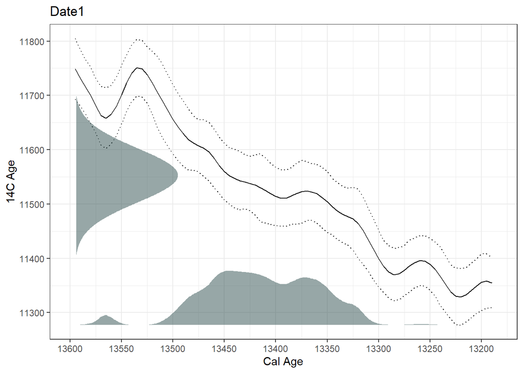

```r
BchronCalibrate(ages=c(11553),
                ageSds=c(50),
                calCurves=c('intcal20')) |>
plot(includeCal = TRUE)
```

# Calibrating radiocarbon dates in R

Here we’ll experiment with calibrating radiocarbon dates, using various calibration curves. Radiocarbon dated samples come back from the lab with a radiocarbon age and standard deviation, among other information. These two bits of information are used to calibrate the radiocarbon dates to estimated ages. R packages may have useful vignettes (package tutorials) and built-in datasets that provide handy test templates. The following code is modified from the `Bchron` [vignette](https://cran.r-project.org/web/packages/Bchron/vignettes/Bchron.html).

**Code**

```r
ages = BchronCalibrate(ages=c(3445,11553,7456),
                        ageSds=c(50,230,110),
                        calCurves=c('intcal20','intcal20','intcal20'))
```

**Summary**

```r
summary(ages)
```

```
95% Highest density regions for Date1
$`94.4%`
[1] 3572 3834


95% Highest density regions for Date2
$`0.4%`
[1] 13004 13025

$`77.9%`
[1] 13059 13874

$`16.4%`
[1] 13923 14012


95% Highest density regions for Date3
$`94.6%`
[1] 8022 8423
```

**Plots**

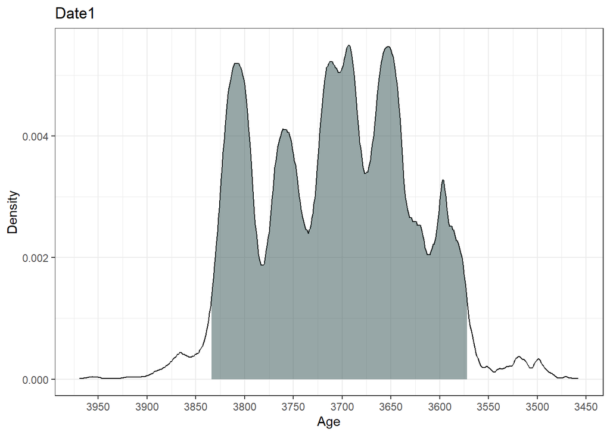

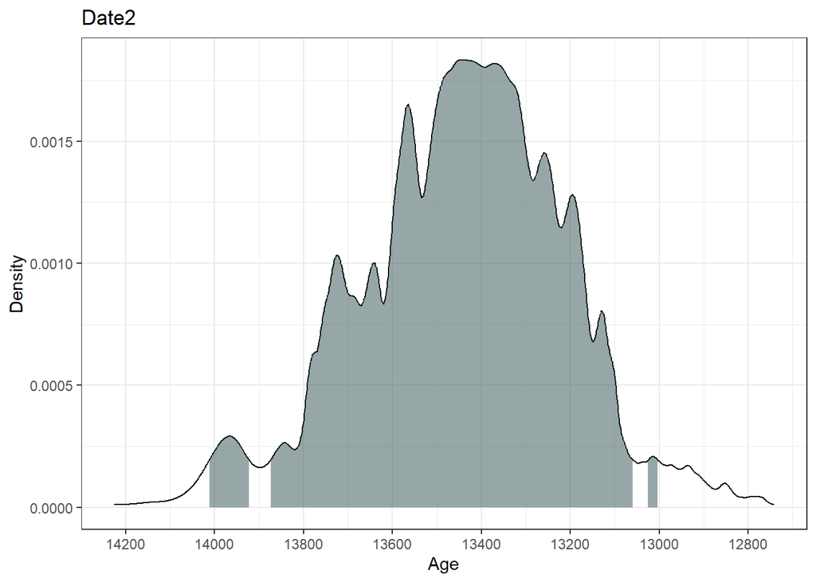

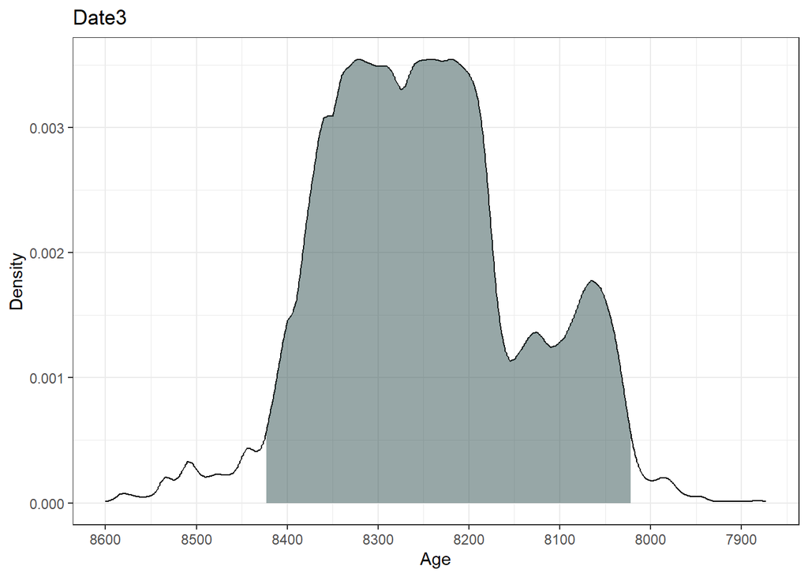

```r
plot(ages)
```

**Calibration curve plots**

```
`height` was translated to `width`.
```

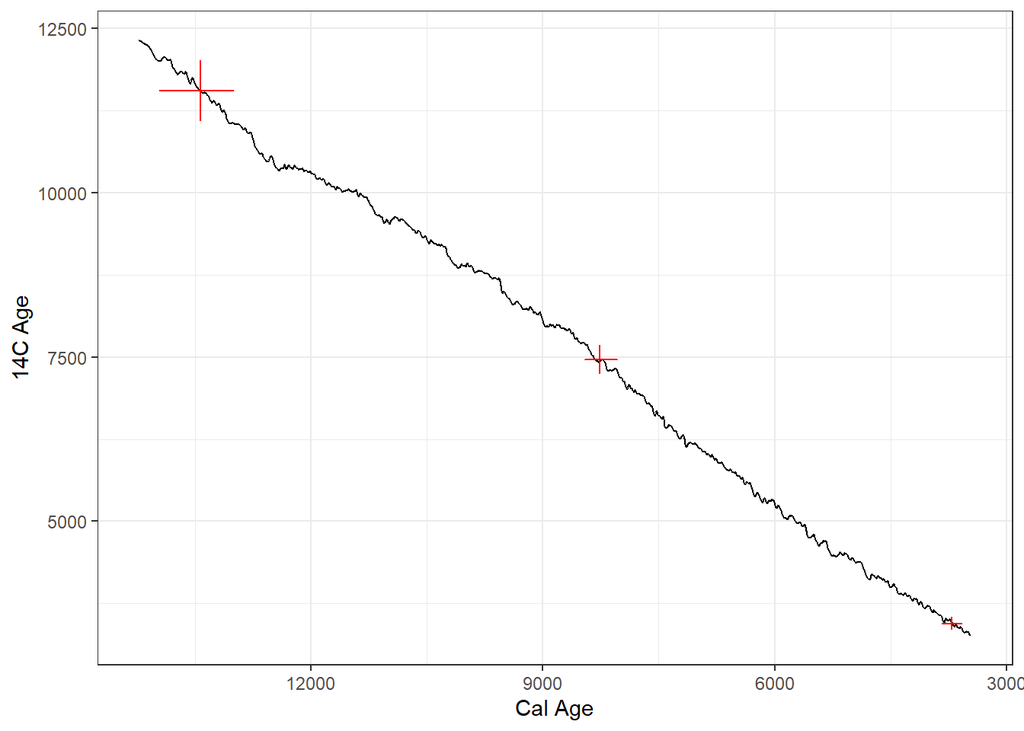

```r
plot(ages, includeCal = TRUE, fillCol = 'red')
```

The output summary indicates the range of the highest density regions (i.e., the most likely ‘real’ age range of the sample). The `plot` function in `Bchron` outputs a `ggplot` object of the high density regions of the most likely ages.

## Your turn

The `BchronCalibrate()` example above uses three arguments: (i) uncalibrated ages (the estimated date returned from the lab); (ii) a standard deviation associated with each of the ages; (iii) a calibration curve associated with each of the dates. Take 5 minutes to:

- Experiment with calibrating a few different ages and standard deviations
  - try a few single ages and plot the calibration curve as shown in Section 1.1
  - also try a few dates at once as in Section 2
- check the function documentation for different calibration curves and try the southern hemisphere calibration.

Give a ✋ in zoom if you have questions and ✅ when you have managed to calibrate and inspect a few different dates.

We will go through a couple of examples together.

# Types of Age-Depth Models

Different kinds of age-depth models exist, each with their own underlying assumptions and behavior. In the list below, #1-4 are classical or traditional forms of age-depth models, but Bayesian models are now the norm. The packages `rbacon` (usually referred to as ‘bacon’) and `Bchron` are the current standards for Bayesian age-depth modelling. Before going to bayesian models, we’ll begin with the classics.

1. **Linear interpolation**, a.k.a. ‘connect the dots,’ in which straight lines are drawn between each depth-adjacent pair of age controls.
2. **Linear regression** ($y=b0~ + b1x$; $y=$time and $x=$depth; $b0$ and $b1$ are constants), in which a single straight line is fitted through the entire set of age controls. In ordinary linear regression (OLS), the chosen line will minimize the y-dimension distances of individual points to the line. Standard OLS assumes that all observations are normally distributed, which is a poor assumption for calibrated radiocarbon dates.
3. **Polynomials**, also fitted to the entire set of age controls ($y= b0 + b1x + b2x^2 + b3x^3 + …bnx^n$), are an extension of linear regression, with additional terms for $x^2$, $x^3$, etc. Some arbitrary maximum n is chosen, usually in the range of 3 to 5. These are called ‘third-order polynomials,’ ‘fifth-order polynomials,’ etc.
4. **Splines**, which are a special kind of polynomial function that are locally fitted to subsets of the age controls, and then smoothly interpolated between points. (Several different formulas can be used to generate splines; common forms include cubic, smooth, monotonic, and LOWESS).
5. **Bayesian age models** (e.g. `bacon`, `bchron`, `oxcal`, etc.). Bayesian models differ in detail, but all combine a statistical representation of prior knowledge with the new data (i.e. the age controls at a site) to build an age-depth model with posterior estimates of age for any given depth. Bayesian models are now widely used because:
   1. they allow the incorporation of prior knowledge (e.g., from coring many lakes, we now have decent estimates of typical sediment accumulation rates, Goring et al. (2012));
   2. they can handle highly irregular probability distribution functions such as those for radiocarbon dates after calibration; and as a result
   3. they generally do a better job of describing uncertainty than traditional age-depth models.

## Classical age-depth models

Classical models are now out-dated methods (Blaauw et al. 2018), but it is useful to understand how they work as literature before the relatively recent development of Bayesian methods has relied on them. Let’s explore some classical methods of age-depth modelling using one of the datasets included with the `Bchron` package. The data are from a core in Northern Ireland; Sluggan Bog Smith and Goddard (1991), and can be called via:

```r
data(Sluggan) # Call the data from Bchron
print(Sluggan) # Check out the data
```

**Linear interpolation**

Linear interpolation predicts ages by simply, drawing a line between successive dated samples. This method assumes that there is a constant age-depth relationship between samples. An assumption that is unlikely to be true, especially of cores with fewer dated samples than Sluggan Moss.

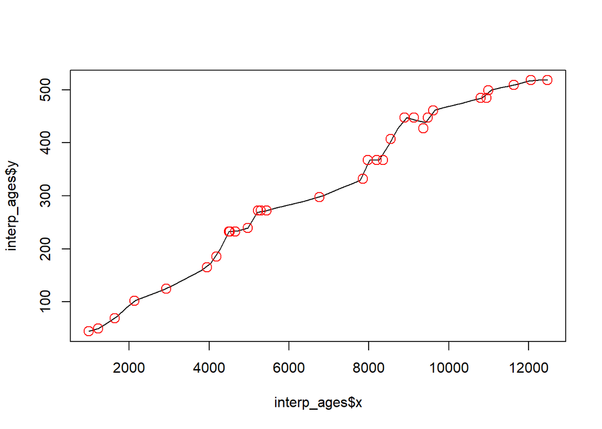

```r
interp_ages <- approx(x = Sluggan$ages, y = Sluggan$position) # use the function approx() to interpolate between ages
plot(x = interp_ages$x, y = interp_ages$y, type = 'l') # Plot the interpolated data
points(x = Sluggan$ages, y = Sluggan$position, cex = 1.5, col = 'red') # overlay the original age points
```

**Linear regression**

Linear regression provides a line of best fit through the dated samples. This method assumes a constant age-depth relationship across all samples, also unlikely to be true depending on processes affecting the core during its formation.

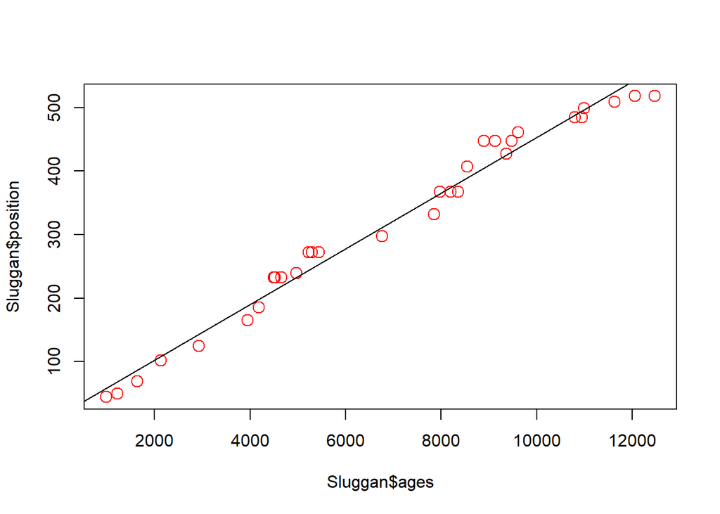

```r
mod_ages <- lm(Sluggan$position ~ Sluggan$ages) # Create a linear regression model
plot(x = Sluggan$ages, y = Sluggan$position, cex = 1.5, col = 'red') # Plot the original ages
abline(mod_ages) # add the regression line from the regression model
```

**Polynomial regression**

Polynomial regression allows a curve to be fit through the data. The amount the curve ‘wiggles’ depends on the order of the polynomial fit to the data. Polynomial regression has the risk of being over-fit.

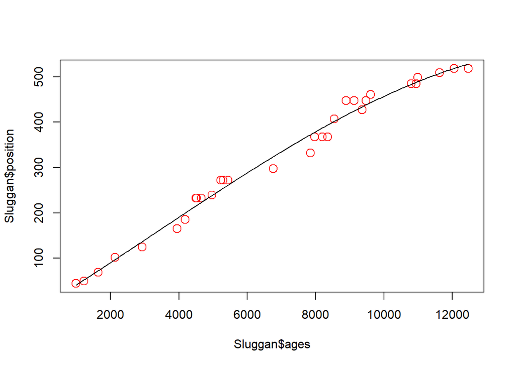

```r
x <- Sluggan$ages # Renaming the variables because the predict function below is fussy about the input name
y <- Sluggan$position
poly_ages <- lm(y ~ poly(x, 3))

plot(x = Sluggan$ages, y = Sluggan$position, cex = 1.5, col = 'red')
age_range <- seq(from = range(Sluggan$ages)[1], to = range(Sluggan$ages)[2], length.out = 250)
lines(age_range, predict(poly_ages, data.frame(x = age_range)))
```

**Cubic splines**

Splines are a class of functions including, for example, smoothing splines or cubic splines. Cubic splines are pieve-wise polynomials locally between ‘knots’. That is the data are split into bins that are fit independently using. By default, the `bs()` function uses a third degree polynomial. Without providing knots the fit will look the same as a third degree polynomial regression.

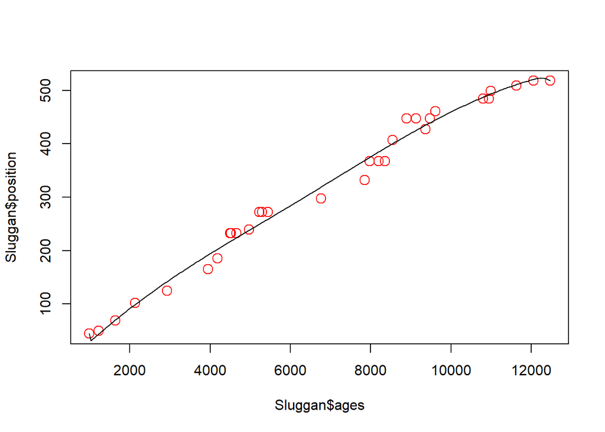

```r
cubic_ages <- lm(y ~ bs(x, knots = c(1000, 6000, 12000)))
plot(x = Sluggan$ages, y = Sluggan$position, cex = 1.5, col = 'red')
lines(age_range, predict(cubic_ages, data.frame(x = age_range)))
```

Because classical age-depth modelling is rarely used now we are not going to delve further into the statistical details of the best way of fitting each model (e.g., the number of knots to use for fitting a cubic spline).

One of the issues with classical age-depth modelling is that uncertainty *decreases* with fewer datapoints.

# Bayesian age-depth models

Now let’s see what the latest methods show for the same dataset. The Sluggan dataset has a lot of radiocarbon dates! We are going to experiment by reducing the number and placement of radiocarbon samples through the core and seeing the affect on the model prediction and uncertainty.

**Code**

Note that all the values provided to the arguments are contained in the Sluggan dataframe. When creating chronologies from your own (or accessed data), you may need to rename them to match your data.

```r
set.seed(1984) # The models are stochastic, good idea to set the seed for reproducibility
SlugganOut = with(Sluggan,
               Bchronology(ages=ages,
                           ageSds=ageSds,
                           calCurves=calCurves,
                           positions=position,
                           positionThicknesses=thickness,
                           ids=id,
                           predictPositions=c(
                             seq(min(Sluggan$position), max(Sluggan$position), by=10),
                             518))
               )
```

**Summary**

The summary shows for each position (depth) the median and quartiles of the predicted ages for that position.

```r
summary(SlugganOut)
```

```
Quantiles of predicted ages by depth:
 Depth      2.5%      25%     50%      75%     97.5%
     0   -60.000    95.75   253.5   450.25   730.000
    10    29.875   246.50   409.0   569.25   789.050
    20   141.950   379.75   536.5   670.75   830.075
    30   271.900   540.00   671.0   762.50   879.000
    40   501.700   723.25   795.0   859.00   928.025
    50   963.975  1071.75  1131.0  1199.25  1333.025
    60  1148.875  1269.00  1334.0  1399.00  1530.050
    70  1401.975  1495.00  1551.0  1616.00  1756.075
    80  1514.000  1653.00  1739.0  1831.00  2016.025
    90  1607.950  1811.00  1906.0  1994.25  2159.025
   100  1855.925  2010.75  2076.0  2165.25  2276.025
   110  2166.950  2369.75  2474.0  2609.25  2900.075
   120  2407.950  2721.75  2843.0  2941.00  3129.000
```

[output cut: 39 more lines]

**Outliers**

The summary shows possible outliers per date.

```r
summary(SlugganOut, type = "outliers")
```

```
Posterior outlier probability by date:
    Date OutlierProb
 UB-201A       0.014
 UB-211A       0.013
  UB-437       0.004
  UB-748       0.005
  UB-438       0.003
  UB-439       0.006
  UB-440       0.009
 UB-219D       0.012
 UB-219B       0.008
 UB-219A       0.010
  UB-441       0.010
 UB-220D       0.031
 UB-220A       0.019
 UB-220E       0.018
 UB-221A       0.010
  UB-749       0.012
 UB-223B       0.133
 UB-223A       0.020
 UB-223D       0.150
  UB-442       0.009
  UB-443       0.042
 UB-225B       0.203
 UB-225D       0.011
 UB-225F       0.025
  UB-444       0.008
 UB-227D       0.008
 UB-227F       0.015
  UB-446       0.009
  UB-447       0.004
 UB-229D       0.012
 UB-229F       0.047
```

**Plot**

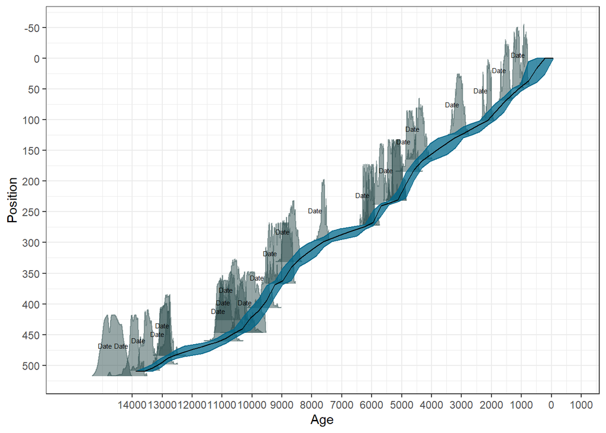

```r
plot(SlugganOut)
```

**Median and mean ages**

Commonly, only the median age is reported; however, it is good practice to report and consider the range of possible ages, especially when exploring synchroneity of events across space. Notice how `Bchron` focuses on delivering ranges and densities.

## Your turn

The `Sluggan` data provide a great in-built working dataset for us to play with. Take 5 minutes to:

- load up the `Sluggan` dataset (`data(Sluggan)`)
- sample the dataset to reduce the number of rows(`Sluggan2 <- Sluggan[c(1, 10, 31), ]`)
- Run and plot the `Bchron` age-depth model

Give a ✋ in zoom if you have questions and ✅ when you have managed to calibrate and inspect a few different dates.

Who has a figure they are willing to share?

Let’s discuss how the output changes depending on the placement and number of chronological controls

- Now edit the `predictPositions` argument. This argument expects a depth sequence. Currently it is set as a sequence for every 10 cm (plus the core bottom at 518 cm). Try different depth resolutions (careful of the run time, if you go for a 1 cm sequence then it will take a while to run!).

## Accumulation rate

Now that we have an age-depth model, we can also obtain the accumulation rates:

```r
acc_rate <- summary(SlugganOut,
  type = "acc_rate",
  probs = c(0.25, 0.5, 0.75)
)
```

And visualise them:

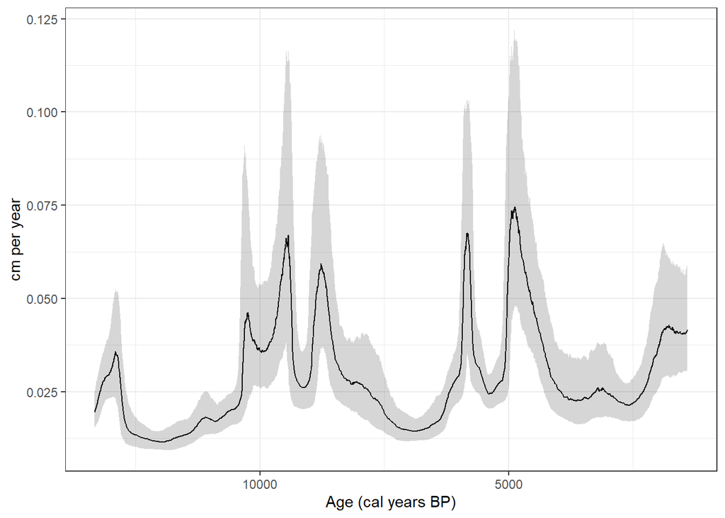

```r
ggplot2::ggplot(acc_rate, aes(
  x = age_grid, y = `50%`,
  ymax = `75%`, ymin = `25%`)) +
  geom_line() +
  geom_ribbon(alpha = 0.2) +
  theme_bw() +
  scale_x_reverse() +
  labs(
    y = "cm per year",
    x = "Age (cal years BP)"
  )
```

# Neotoma example

So far we have used the built-in dataset from the northern hemisphere for the sake of demonstration. But let’s now follow an example by pulling data from the neotoma database. Although this is not a `neotoma2` tutorial, we can cover rebuilding a chronology if we still have time.

The following code will download data from the neotoma database. I have also saved some example datasets in the data directory just in case the neotoma API is under maintenance or there are download speed issues. If you have your own data or would like to download a site of your choice from neotoma feel free to do that. [neotoma explorer](https://apps.neotomadb.org/explorer/index.html) can help you find a site id.

site IDs:

- Laguna Padre Laguna <- 10063 (Argentina)
- Mallin Book <- 1639 (Argentina)
- Harberton <- 10136 ()
- Lago Puerto Arturo <- 28348 (Guatemala)
- Albatross Lake <- 28408 (Marion Island)
- Lake Edward <- 26660
- Lake Victoria II <- 31747 (Uganda linear interpolation)
- Lake Kirkpatrick <- 9865
- Lake Frome <- 28489 (Auestrailia)

```r
if (!file.exists(file.path("./data/some_sites.rds"))) {
  site_ids <- c(10063, 1639, 10136, 28408, 9865, 28489, 31732)
  some_sites <- neotoma2::get_sites(site_ids)
  neotoma2::plotLeaflet(some_sites)
  saveRDS(some_sites, "./data/some_sites.rds")
} else {
  some_sites <- readRDS("./data/some_sites.rds")
}
```

```r
if (!file.exists(file.path("./data/some_datasets.rds"))) {

  some_datasets <-
    neotoma2::get_datasets(some_sites, all_data = TRUE) |>
    neotoma2::filter(datasettype == "pollen" & !is.na(age_range_young)) |>
    neotoma2::get_downloads()

  saveRDS(some_datasets, "./data/some_datasets.rds")
} else {
  some_datasets <- readRDS("./data/some_datasets.rds")
}
```

```r
controls <- neotoma2::chroncontrols(some_datasets[[1]]) |>
  dplyr::filter(chronologyid == 33123) |> # If there is more than on chronology
  dplyr::arrange(depth)
```

```r
newChron <- Bchron::Bchronology(
  ages = controls$chroncontrolage,
  ageSds = abs(controls$agelimityounger -
               controls$chroncontrolage),
  calCurves = c("normal", rep("intcal20", 9)),
  positions = controls$depth,
  positionThicknesses = controls$thickness,
  ids = controls$chroncontrolid,
  predictPositions=
      seq(min(controls$depth), max(controls$depth), by=10))
```

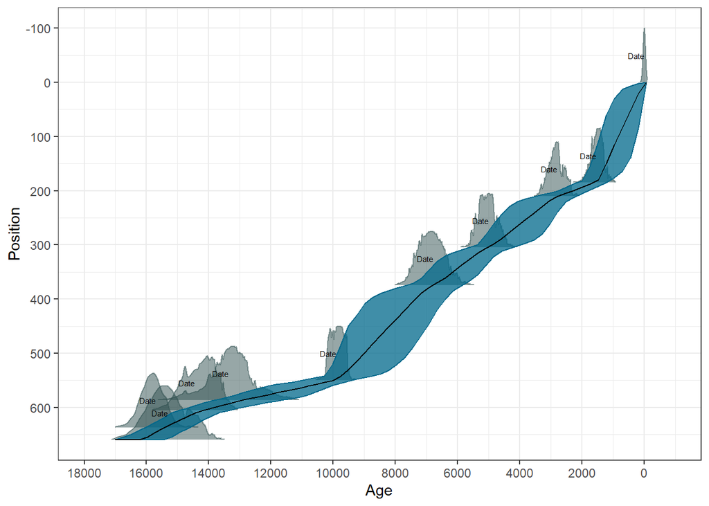

```r
plot(newChron)
```

**Resources**

Age-depth modelling is complicated, there are many pitfalls, assumptions, and uncertainties that are often ignored. Recent developments have begun to focus on quantifying uncertainties to understand the reliability of inferences made from the data. Key papers for understanding age depth modelling include:

- The Bchron [vignette](https://cran.r-project.org/web/packages/Bchron/vignettes/Bchron.html) is also a useful resource.
- Blaauw et al. (2018)
- Parnell et al. (2008)
- Trachsel and Telford (2017)

Blaauw, Maarten, J. Andrés Christen, K. D. Bennett, and Paula J. Reimer. 2018. “Double the Dates and Go for Bayes — Impacts of Model Choice, Dating Density and Quality on Chronologies.” *Quaternary Science Reviews* 188 (May): 58–66. https://doi.org/10.1016/j.quascirev.2018.03.032.

Blois, Jessica L., John W. (Jack) Williams, Eric C. Grimm, Stephen T. Jackson, and Russell W. Graham. 2011. “A Methodological Framework for Assessing and Reducing Temporal Uncertainty in Paleovegetation Mapping from Late-Quaternary Pollen Records.” *Quaternary Science Reviews* 30 (15-16): 1926–39. https://doi.org/10.1016/j.quascirev.2011.04.017.

Goring, S., J. W. Williams, J. L. Blois, S. T. Jackson, C. J. Paciorek, R. K. Booth, J. R. Marlon, M. Blaauw, and J. A. Christen. 2012. “Deposition Times in the Northeastern United States During the Holocene: Establishing Valid Priors for Bayesian Age Models.” *Quaternary Science Reviews* 48 (August): 54–60. https://doi.org/10.1016/j.quascirev.2012.05.019.

Mottl, Ondřej, Suzette G. A. Flantua, Kuber P. Bhatta, Vivian A. Felde, Thomas Giesecke, Simon Goring, Eric C. Grimm, et al. 2021. “Global Acceleration in Rates of Vegetation Change over the Past 18,000 Years.” *Science* 372 (6544): 860–64. https://doi.org/10.1126/science.abg1685.

Parnell, A. C., J. Haslett, J. R. M. Allen, C. E. Buck, and B. Huntley. 2008. “A Flexible Approach to Assessing Synchroneity of Past Events Using Bayesian Reconstructions of Sedimentation History.” *Quaternary Science Reviews* 27 (19-20): 1872–85. https://doi.org/10.1016/j.quascirev.2008.07.009.

Ramsey, C. Bronk. 2008. “Radiocarbon Dating: Revolutions in Understanding.” *Archaeometry* 50 (2): 249–75. https://doi.org/10.1111/j.1475-4754.2008.00394.x.

Reimer, Paula J, William E N Austin, Edouard Bard, Alex Bayliss, Paul G Blackwell, Christopher Bronk Ramsey, Martin Butzin, et al. 2020. “The IntCal20 Northern Hemisphere Radiocarbon Age Calibration Curve (0–55 Cal kBP).” *Radiocarbon* 62 (4): 725–57. https://doi.org/10.1017/RDC.2020.41.

Smith, A. G., and I. C. Goddard. 1991. “A 12500 Year Record of Vegetational History at Sluggan Bog, Co. Antrim, N. Ireland (Incorporating a Pollen Zone Scheme for the Non-Specialist).” *The New Phytologist* 118 (1): 167–87. https://www.jstor.org/stable/2557698.

Trachsel, Mathias, and Richard J Telford. 2017. “All Age–Depth Models Are Wrong, but Are Getting Better.” *The Holocene* 27 (6): 860–69. https://doi.org/10.1177/0959683616675939.